# Principal Components Analysis

## Flavien Deseure–Charron

## 29/10/2021

## Loading Data

#### 1. Download the iris dataset from here and import it into .

```r
iris = read.table('https://www.mghassany.com/MLcourse/datasets/iris.data', header=T, sep=",")
iris
```

| sepal_length | sepal_width | petal_length | petal_width | class |
| --- | --- | --- | --- | --- |
| 5.1 | 3.5 | 1.4 | 0.2 | setosa |
| 4.9 | 3.0 | 1.4 | 0.2 | setosa |
| 4.7 | 3.2 | 1.3 | 0.2 | setosa |
| 4.6 | 3.1 | 1.5 | 0.2 | setosa |
| 5.0 | 3.6 | 1.4 | 0.2 | setosa |
| 5.4 | 3.9 | 1.7 | 0.4 | setosa |
| 4.6 | 3.4 | 1.4 | 0.3 | setosa |
| 5.0 | 3.4 | 1.5 | 0.2 | setosa |
| 4.4 | 2.9 | 1.4 | 0.2 | setosa |
| 4.9 | 3.1 | 1.5 | 0.1 | setosa |

[output cut: 140 more lines]

## Exploratory analysis

#### 2. Compare the means and the quartiles of the 3 different flower classes for the 4 different features (Plot 4 boxplots into the same figure).

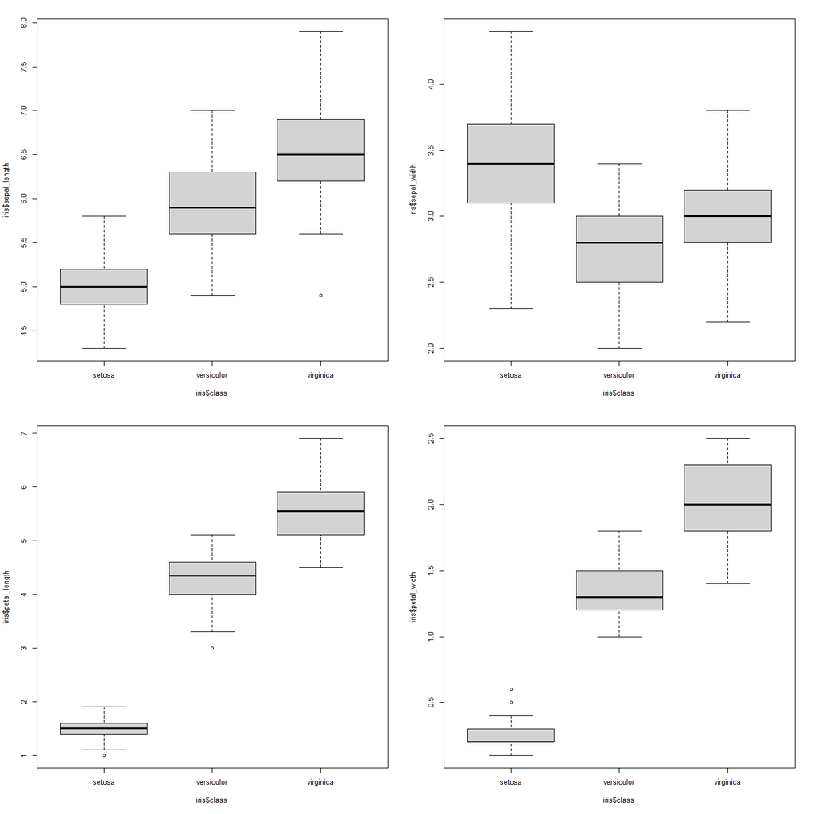

#### 3. To explore how the 3 different flower classes are distributed along the 4 different features, visualize them via histograms using the following code.

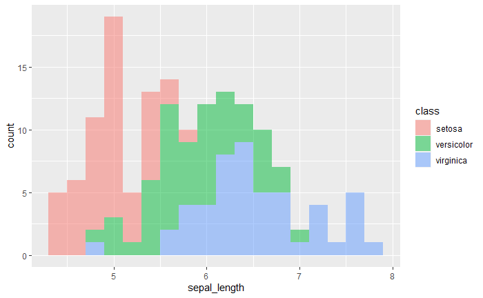

```r
# Let's use the ggplot2 library
# ggplot2 is the most advanced package for data visualization
# gg corresponds to The Grammar of Graphics.
library(ggplot2) #of course you must install it first if you don't have it already

# histogram of sepal_length
ggplot(iris, aes(x=sepal_length, fill=class)) +
  geom_histogram(binwidth=.2, alpha=.5)
```

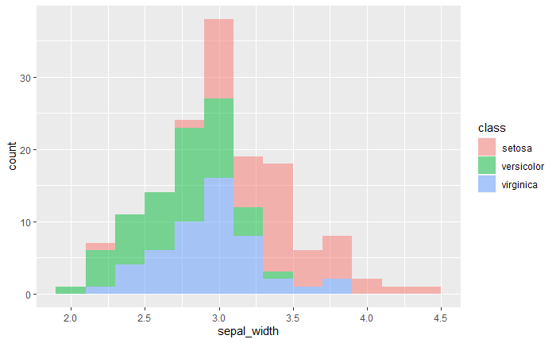

```r
# histogram of sepal_width
ggplot(iris, aes(x=sepal_width, fill=class)) +
  geom_histogram(binwidth=.2, alpha=.5)
```

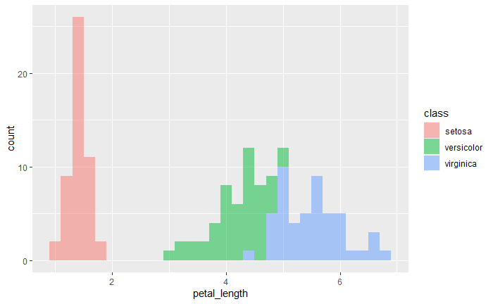

```r
# histogram of petal_length
ggplot(iris, aes(x=petal_length, fill=class)) +
  geom_histogram(binwidth=.2, alpha=.5)
```

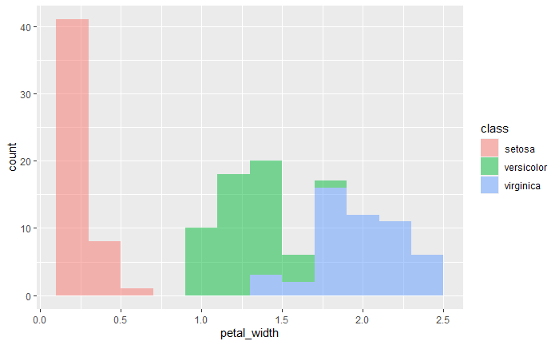

```r
# histogram of petal_width
ggplot(iris, aes(x=petal_width, fill=class)) +
  geom_histogram(binwidth=.2, alpha=.5)
```

## PCA using princomp()

#### 4. Apply a PCA on the Iris dataset using the princomp() function and interpret the results.

```r
pcairis=princomp(iris[,-5], cor=T)

# Note that we take only the numerical columns to apply PCA.
# now pcairis is a R object of type princomp
# To display the internal structure of pcairis
str(pcairis)
```

```
List of 7
 $ sdev    : Named num [1:4] 1.706 0.96 0.384 0.144
  ..- attr(*, "names")= chr [1:4] "Comp.1" "Comp.2" "Comp.3" "Comp.4"
 $ loadings: 'loadings' num [1:4, 1:4] 0.522 -0.263 0.581 0.566 0.372 ...
  ..- attr(*, "dimnames")=List of 2
  .. ..$ : chr [1:4] "sepal_length" "sepal_width" "petal_length" "petal_width"
  .. ..$ : chr [1:4] "Comp.1" "Comp.2" "Comp.3" "Comp.4"
 $ center  : Named num [1:4] 5.84 3.05 3.76 1.2
  ..- attr(*, "names")= chr [1:4] "sepal_length" "sepal_width" "petal_length" "petal_width"
 $ scale   : Named num [1:4] 0.825 0.432 1.759 0.761
  ..- attr(*, "names")= chr [1:4] "sepal_length" "sepal_width" "petal_length" "petal_width"
 $ n.obs   : int 150
 $ scores  : num [1:150, 1:4] -2.26 -2.09 -2.37 -2.3 -2.39 ...
  ..- attr(*, "dimnames")=List of 2
  .. ..$ : NULL
  .. ..$ : chr [1:4] "Comp.1" "Comp.2" "Comp.3" "Comp.4"
 $ call    : language princomp(x = iris[, -5], cor = T)
 - attr(*, "class")= chr "princomp"
```

```r
# To see the variance explained by the the pcs
summary(pcairis)
```

```
Importance of components:
                          Comp.1    Comp.2     Comp.3      Comp.4
Standard deviation     1.7061120 0.9598025 0.38386622 0.143553848
Proportion of Variance 0.7277045 0.2303052 0.03683832 0.005151927
Cumulative Proportion  0.7277045 0.9580098 0.99484807 1.000000000
```

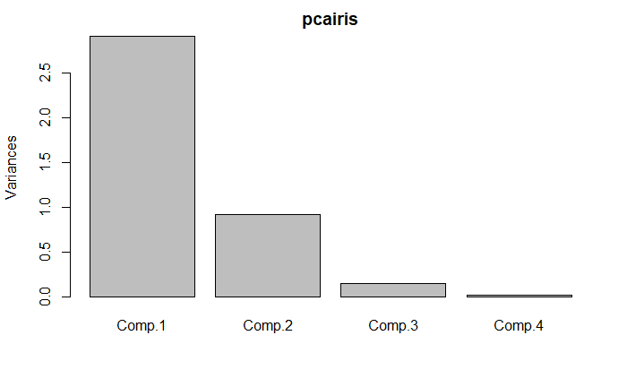

```r
# To plot the variance explained by each pc
plot(pcairis)
```

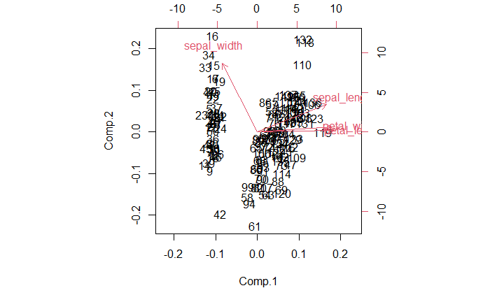

```r
# To plot together the scores for PC1 and PC2 and the
# variables expressed in terms of PC1 and PC2.
biplot(pcairis)
```

## Deeper PCA using factoextra package

#### 5. Using factoextra package plot the following:

- The scree plot.
- The graph of individuals.
- The graph of variables.
- The biplot graph.
- The contributions of the variables to the first 2 principal components.

```r
library(factoextra)
```

##### Screeplot

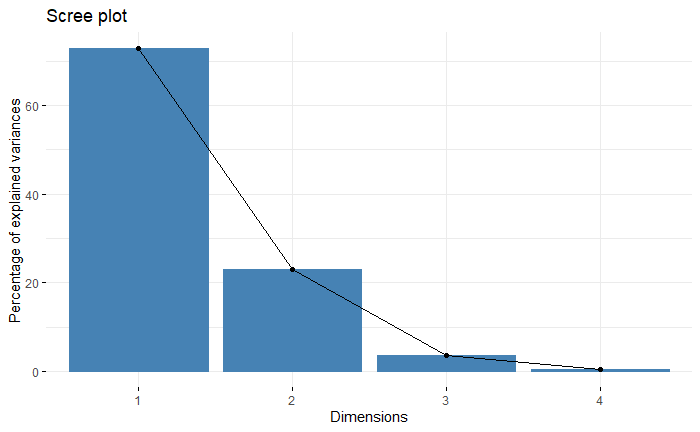

```r
fviz_eig(pcairis)
```

##### The graph of individuals

```r
ind <- get_pca_ind(pcairis)
ind
```

```
Principal Component Analysis Results for individuals
 ===================================================
  Name       Description
1 "$coord"   "Coordinates for the individuals"
2 "$cos2"    "Cos2 for the individuals"
3 "$contrib" "contributions of the individuals"
```

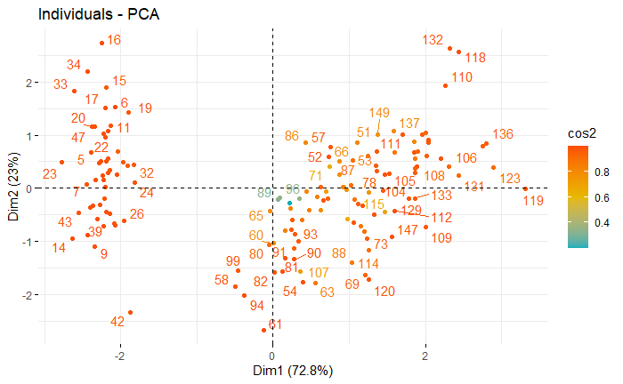

```r
fviz_pca_ind (pcairis, col.ind = "cos2",
             gradient.cols = c("#00AFBB", "#E7B800", "#FC4E07"),
             repel = TRUE
             )
```

##### The graph of variables

```r
var = get_pca_var(pcairis)
var
```

```
Principal Component Analysis Results for variables
 ===================================================
  Name       Description
1 "$coord"   "Coordinates for the variables"
2 "$cor"     "Correlations between variables and dimensions"
3 "$cos2"    "Cos2 for the variables"
4 "$contrib" "contributions of the variables"
```

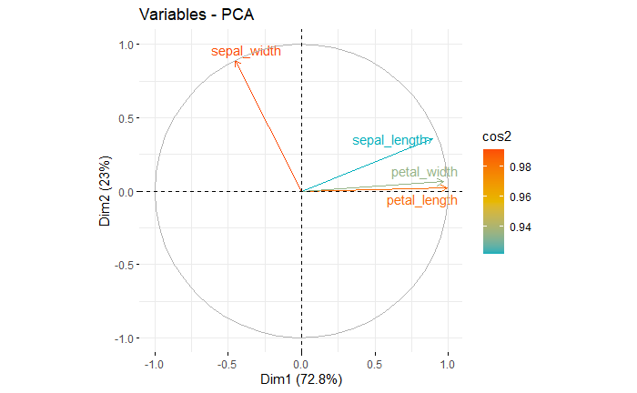

```r
fviz_pca_var(pcairis, col.var = "cos2",
             gradient.cols = c("#00AFBB", "#E7B800", "#FC4E07"),
             repel = TRUE # Évite le chevauchement de texte
             )
```

##### The biplot graph

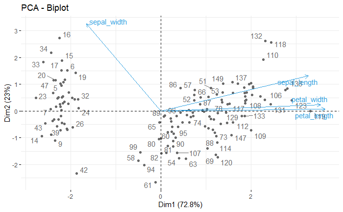

```r
fviz_pca_biplot(pcairis, repel = TRUE,
                col.var = "#2E9FDF", # Couleur des variables
                col.ind = "#696969"  # Couleur des individues
                )
```

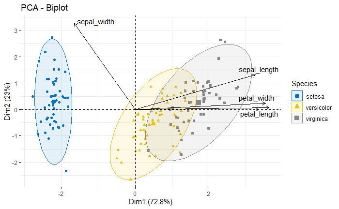

```r
fviz_pca_biplot (pcairis,
                col.ind = iris$class, palette = "jco",
                addEllipses = TRUE, label = "var",
                col.var = "black", repel = TRUE,
                legend.title = "Species")
```

##### The contributions of the variables to the first 2 principal components

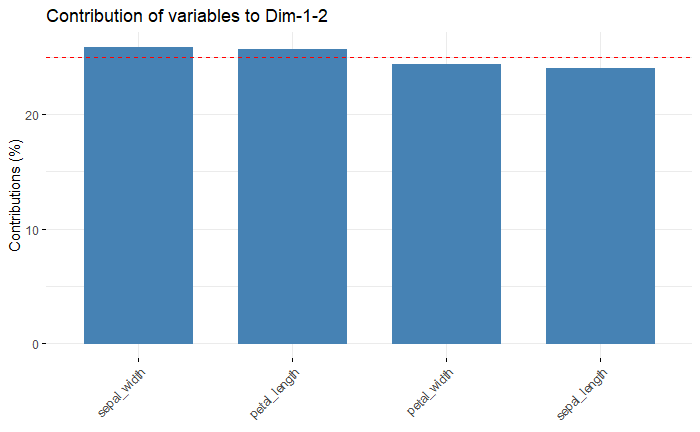

```r
fviz_contrib(pcairis, choice = "var", axes = 1:2)
```

## Step-by-step PCA

1. Normalize data
2. Calculate cov matrix
3. Calculate eigenvalues/eigenvectors
4. Pick K eigenvalues/eigenvector
5. Find Most important

#### 6. First step, split the iris dataset into data X and class labels y

```r
X <- iris[,-5]
y <- iris[,5]
```

### Standardizing

#### 7. Scale the 4 features. Store the scaled matrix into a new one (for example, name it X_scaled).

```r
X_scaled = scale(X)
```

### Covariance Matrix

#### 8. The classic approach to PCA is to perform the eigendecomposition on the covariance matrix Σ, which is a p×p matrix where each element represents the covariance between two features. Compute the Covariance Matrix of the scaled features (Print the results).

```r
sigma = cov(X_scaled)
sigma
```

```
             sepal_length sepal_width petal_length petal_width
sepal_length    1.0000000  -0.1093692    0.8717542   0.8179536
sepal_width    -0.1093692   1.0000000   -0.4205161  -0.3565441
petal_length    0.8717542  -0.4205161    1.0000000   0.9627571
petal_width     0.8179536  -0.3565441    0.9627571   1.0000000
```

#### 9. Perform an eigendecomposition on the covariance matrix. Compute the Eigenvectors and the Eigenvalues (you can use the eigen() function). What do you obtain?

```r
eigens = eigen(sigma)
print(eigens$values)
```

```
[1] 2.91081808 0.92122093 0.14735328 0.02060771
```

```r
print(eigens$vectors)
```

```
           [,1]        [,2]       [,3]       [,4]
[1,]  0.5223716 -0.37231836  0.7210168  0.2619956
[2,] -0.2633549 -0.92555649 -0.2420329 -0.1241348
[3,]  0.5812540 -0.02109478 -0.1408923 -0.8011543
[4,]  0.5656110 -0.06541577 -0.6338014  0.5235463
```

We obtain a table of eigenvalues and corresponding eigenvectors.

### Correlation Matrix

#### 10. Perform an eigendecomposition of the standardized data based on the correlation matrix.

```r
eigens_corr = eigen(cor(X_scaled))
print(eigens_corr$values)
```

```
[1] 2.91081808 0.92122093 0.14735328 0.02060771
```

```r
print(eigens_corr$vectors)
```

```
           [,1]        [,2]       [,3]       [,4]
[1,]  0.5223716 -0.37231836  0.7210168  0.2619956
[2,] -0.2633549 -0.92555649 -0.2420329 -0.1241348
[3,]  0.5812540 -0.02109478 -0.1408923 -0.8011543
[4,]  0.5656110 -0.06541577 -0.6338014  0.5235463
```

#### 11. Perform an eigendecomposition of the raw data based on the correlation matrix. Compare the obtained results with the previous question.

```r
eigens_corr = eigen(cor(X))
print(eigens_corr$values)
```

```
[1] 2.91081808 0.92122093 0.14735328 0.02060771
```

```r
print(eigens_corr$vectors)
```

```
           [,1]        [,2]       [,3]       [,4]
[1,]  0.5223716 -0.37231836  0.7210168  0.2619956
[2,] -0.2633549 -0.92555649 -0.2420329 -0.1241348
[3,]  0.5812540 -0.02109478 -0.1408923 -0.8011543
[4,]  0.5656110 -0.06541577 -0.6338014  0.5235463
```

Eigenvalues and eigenvectors are the same with the three approaches.

### Selecting Principal Components

The eigen() function will, by default, sort the eigenvalues in decreasing order.

### Explained Variance

#### 12. Calculate the individual explained variation and the cumulative explained variation of each principal component. Show the results.

```r
explained_var = eigens$values/sum(eigens$values)
explained_var
```

```
[1] 0.727704521 0.230305233 0.036838320 0.005151927
```

```r
cum_explained_var = cumsum(explained_var)
cum_explained_var
```

```
[1] 0.7277045 0.9580098 0.9948481 1.0000000
```

#### 13. Plot the individual explained variation. (scree plot)

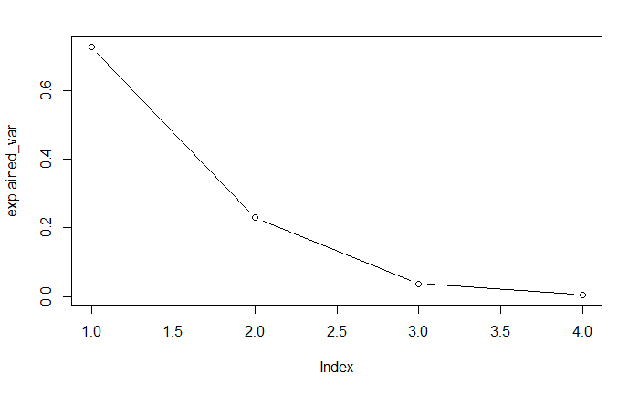

```r
plot(explained_var,type="b")
```

### Projection Matrix

#### 14. Construct the projection matrix that will be used to transform the Iris data onto the new feature subspace.

```r
A = eigens$vectors[,1:2]
A
```

```
           [,1]        [,2]
[1,]  0.5223716 -0.37231836
[2,] -0.2633549 -0.92555649
[3,]  0.5812540 -0.02109478
[4,]  0.5656110 -0.06541577
```

### Projection Onto the New Feature Space

#### 15. Compute Y (Recall the Y is the matrix of scores, A is the matrix of loadings).

```r
Y = X_scaled %*% A
```

### Visualization

#### 16. Plot the observations on the new feature space. Name the axis PC1 and PC2.

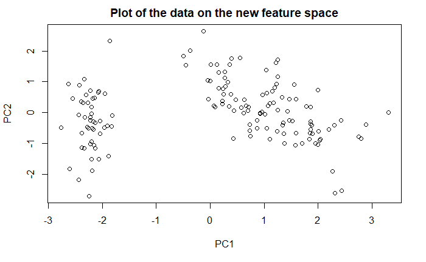

```r
plot(Y, xlab = "PC1", ylab = "PC2", main="Plot of the data on the new feature space")
```

#### 17. On the same plot, color the observations (the flowers) with respect to their flower classes.

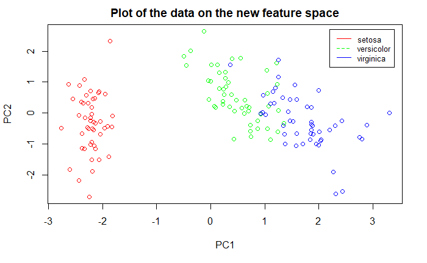

```r
my_cols <- c("red", "green", "blue")
plot(Y,col=my_cols[as.integer(as.factor(iris$class))], xlab = "PC1", ylab = "PC2", main="Plot of the data on the new feature space")
legend(2.2, 2.7, legend=unique(iris$class),
       col=my_cols, lty=1:2, cex=0.8)
```

## References

FISHER, R. A. 1936. “THE USE OF MULTIPLE MEASUREMENTS IN TAXONOMIC PROBLEMS.” Annals of Eugenics 7 (2): 179–88. https://doi.org/10.1111/j.1469-1809.1936.tb02137.x.